# Visualizing child marriage globally

- Show All Code
- Hide All Code
- View Source

Making over a dashboard with a series of plots that tell the story of child marriage

R

#MakeoverMonday

bar-plot

connected-dot-plot

tile-map

Author

[Mickey Rafa](https://mrafa3.github.io/)

Published

October 12, 2020

Every year, millions of children – mostly young girls – have their futures decided for them through child marriage. This isn’t just about numbers in a dataset; it’s about real kids losing their chance to grow, dream, and choose their own paths. While there has been progress, child marriage still happens too often, driven by from poverty and gender power dynamics in societies. Before I worked on this #MakeoverMonday, I wanted to recognize the humanity and pain in this data.

Here’s some more information from [UNICEF’s website](https://www.unicef.org/protection/child-marriage):

> Child marriage refers to any formal marriage or informal union between a child under the age of 18 and an adult or another child. Despite a steady decline in this harmful practice over the past decade, child marriage remains widespread, with approximately one in five girls married in childhood across the globe. Today, multiple crises – including conflict, climate shocks and the ongoing fallout from COVID-19 – are threatening to reverse progress towards eliminating this human rights violation. The United Nations Sustainable Development Goals call for global action to end child marriage by 2030.

Now, here’s the **original plot for #MakeoverMonday**

[figure not shown]

Figure 1: Original graphic depicting the rates of child marriage globally. Source: UNICEF

**My alternative plots**

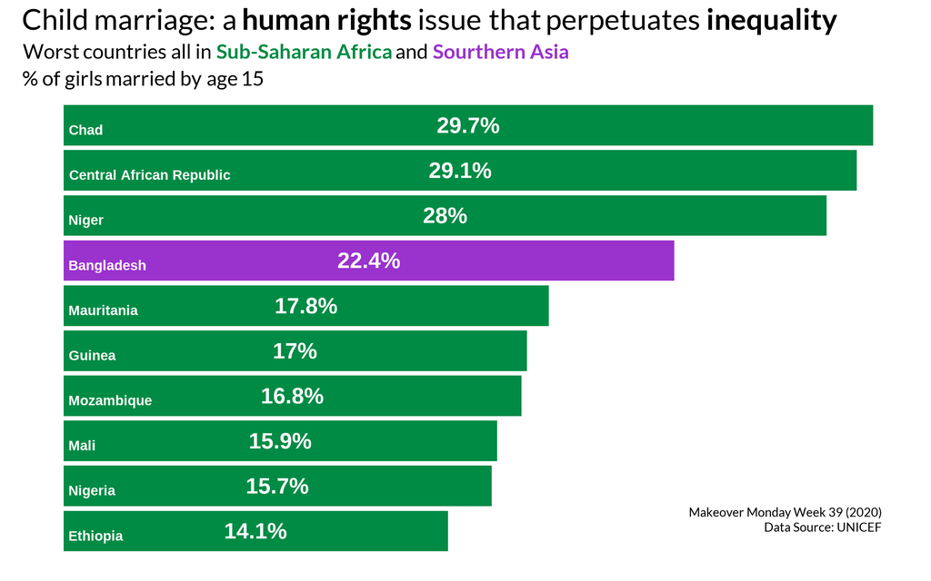

Figure 2: Bar plot visualizing the countries with the 10 highest rates of marriage among girls aged 15. Nine of the top 10 countries are in Africa. Source: UNICEF.

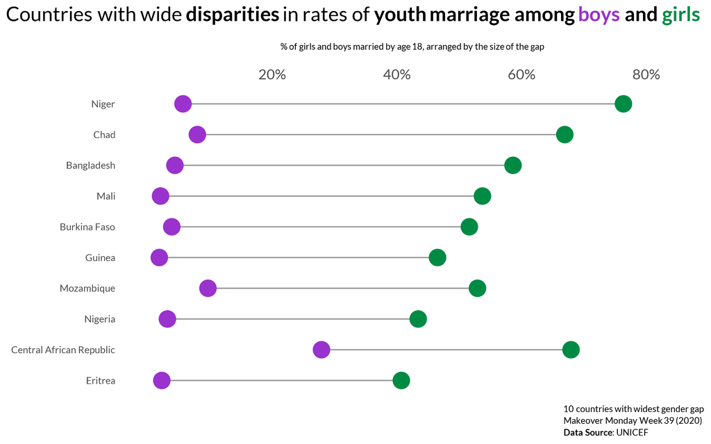

Figure 3: Dumbbell plot displaying the rates of child marriage among girls and boys. The countries shown are the 10 with the largest gender disparities – where the marriage of girls is much higher than that of boys. Source: UNICEF.

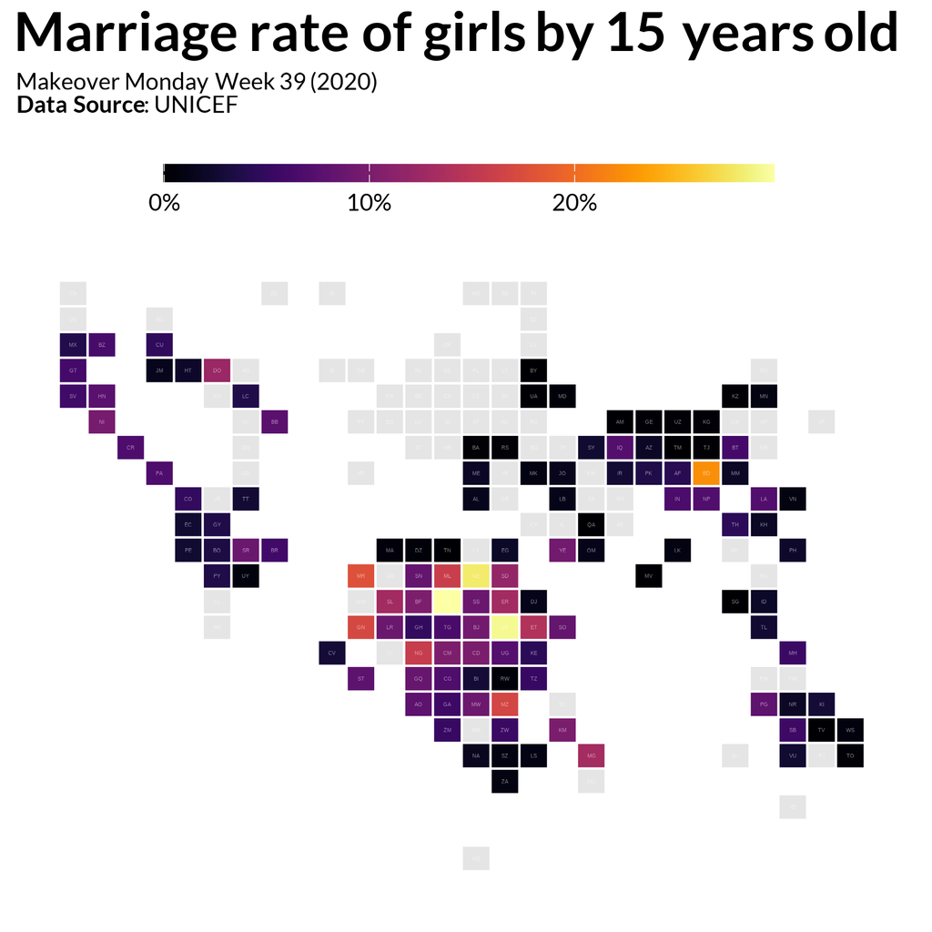

Figure 4: Stylized tile map showing the rate of marriage among girls aged 15. This type of map can be an effective way to communicate geographic patterns, while avoiding some shortcomings of typical map projections, like land area having large differences that can introduce cognitive biases. Source: UNICEF.

# 1. Load Packages & Setup

```r
if (!require("pacman")) install.packages("pacman")
pacman::p_load(
    tidyverse,
    tidytuesdayR,
    dlookr,
    ggtext,
    gt,
    gtExtras,  #for font awesome icons in gt tables
    ggbump,
    ggalt,
    hrbrthemes,
    countrycode,
    showtext,
    janitor,   #for clean_names()
    scales,
    htmltools, #for tagList()
    glue,
    here,
    geomtextpath
)

font_add_google('Lato')
```

# 2. Read in the Data

```r
mm_year <- 2020
mm_week <- 39

df <- read.csv("https://query.data.world/s/qss24rzobvbkg6gc7y7lzfn75c4b46",
               header=TRUE, stringsAsFactors=FALSE) %>%
  clean_names()

tile_data <- read_csv("https://gist.githubusercontent.com/maartenzam/787498bbc07ae06b637447dbd430ea0a/raw/9a9dafafb44d8990f85243a9c7ca349acd3a0d07/worldtilegrid.csv")
```

# 3. Examine the Data

```r
df %>%
  glimpse()
```

```
Rows: 128
Columns: 4
$ country               <chr> "Afghanistan", "Albania", "Algeria", "Angola", "…
$ females_married_by_15 <dbl> 0.04200000, 0.01400000, 0.00400000, 0.07900000, …
$ females_married_by_18 <dbl> 0.2830000, 0.1180000, 0.0250000, 0.3030000, 0.05…
$ males_married_by_18   <dbl> 0.073, 0.012, NA, 0.060, 0.004, 0.004, 0.044, NA…
```

```r
df %>%
  summary()
```

```
   country          females_married_by_15 females_married_by_18
 Length:128         Min.   :0.00000       Min.   :0.0010
 Class :character   1st Qu.:0.01150       1st Qu.:0.1115
 Mode  :character   Median :0.03750       Median :0.2220
                    Mean   :0.05482       Mean   :0.2313
                    3rd Qu.:0.07750       3rd Qu.:0.3070
                    Max.   :0.29700       Max.   :0.7630

 males_married_by_18
 Min.   :0.00000
 1st Qu.:0.01300
 Median :0.03500
 Mean   :0.04777
 3rd Qu.:0.06000
 Max.   :0.27900
 NA's   :33
```

# 4. Tidy the Data

```r
# collect country codes and regions
codelist <- countrycode::codelist %>%
  select(un.name.en, continent,
         un.region.name, un.regionsub.name,
         iso2c) %>%
  rename(country = un.name.en) %>%
  filter(!is.na(country))

# adjust text of some names and join on codelist
df <- df %>%
  mutate(country = recode(country,
                          "Cote d'Ivoire" = "Côte D'Ivoire",
                          "Gambia" = "Gambia (Republic of The)",
                          "Guinea-Bissau" = "Guinea Bissau",
                          "Lao People's Democratic Republic" = "Lao People’s Democratic Republic")) %>%
  left_join(x=.,
            y=codelist,
            by='country')

# Namibia is missing an `alpha.2` code, so correcting that
tile_data <- tile_data %>%
  mutate(alpha.2 = if_else(is.na(alpha.2), 'NA', alpha.2))

# join tile_data with df
tile_data <- tile_data %>%
  left_join(x=.,
            y=df,
            by=c('alpha.2' = 'iso2c'))

# create top 10 dataframes for vizzes
top_10_girls15_df <- df %>%
  slice_max(order_by = females_married_by_15,
            n =10)

top_10_disparity_df <- df %>%
  mutate(diff_by_18 = females_married_by_18 - males_married_by_18) %>%
  slice_max(order_by = diff_by_18, n = 10)
```

# 5. Visualization Parameters

```r
my_theme <- theme(
  text = element_text(family = 'Lato', size=12, color='black'),
  axis.ticks = element_blank(),
  plot.background = element_rect(color='white'),
  panel.background =  element_blank(),
  legend.background = element_blank(),
  panel.grid.major = element_line(colour = "grey90", size = 0.5),
  panel.grid.minor = element_line(colour = "grey93", size = 0.5),
  panel.border = element_blank(),
  legend.title=element_blank(),
  legend.position = 'top')

region_cols <- c('Southern Asia' = 'darkorchid3',
                 'Sub-Saharan Africa' = 'springgreen4')
```